# Recommendation System Project: IBM Community

In this notebook, you will be putting your recommendation skills to use on real data from the IBM Watson Studio platform.

You may either submit your notebook through the workspace here, or you may work from your local machine and submit through the next page. Either way assure that your code passes the project [RUBRIC](https://review.udacity.com/#!/rubrics/3325/view). **Please save regularly.**

By following the table of contents, you will build out a number of different methods for making recommendations that can be used for different situations.

I. Exploratory Data Analysis  
II. Rank Based Recommendations  
III. User-User Based Collaborative Filtering  
IV. Content Based Recommendations  
V. Matrix Factorization  
VI. Extras & Concluding

At the end of the notebook, you will find directions for how to submit your work. Let's get started by importing the necessary libraries and reading in the data.

```python
import pandas as pd
import numpy as np
import matplotlib.pyplot as plt
import project_tests as t


df = pd.read_csv(
    '../data/user-item-interactions.csv',
    dtype={'article_id': int, 'title': str, 'email': str}
)
# Show df to get an idea of the data
df.head()
```

|  | Unnamed: 0 | article_id | title | email |
| --- | --- | --- | --- | --- |
| 0 | 0 | 1430 | using pixiedust for fast, flexible, and easier... | ef5f11f77ba020cd36e1105a00ab868bbdbf7fe7 |
| 1 | 1 | 1314 | healthcare python streaming application demo | 083cbdfa93c8444beaa4c5f5e0f5f9198e4f9e0b |
| 2 | 2 | 1429 | use deep learning for image classification | b96a4f2e92d8572034b1e9b28f9ac673765cd074 |
| 3 | 3 | 1338 | ml optimization using cognitive assistant | 06485706b34a5c9bf2a0ecdac41daf7e7654ceb7 |
| 4 | 4 | 1276 | deploy your python model as a restful api | f01220c46fc92c6e6b161b1849de11faacd7ccb2 |

### Part I : Exploratory Data Analysis

Use the dictionary and cells below to provide some insight into the descriptive statistics of the data.

`1.` Are there any missing values? If so, provide a count of missing values. If there are missing values in `email`, assign it the same id value `"unknown_user"`.

```python
# Some interactions do not have a user associated with it, assume the same user.
df.info()
```

```
<class 'pandas.core.frame.DataFrame'>
RangeIndex: 45993 entries, 0 to 45992
Data columns (total 4 columns):
 #   Column      Non-Null Count  Dtype
---  ------      --------------  -----
 0   Unnamed: 0  45993 non-null  int64
 1   article_id  45993 non-null  int64
 2   title       45993 non-null  object
 3   email       45976 non-null  object
dtypes: int64(2), object(2)
memory usage: 1.4+ MB
```

```python
print(f"Number of Null email values is: {df['email'].isnull().sum()}")
```

```
Number of Null email values is: 17
```

```python
df[df.email.isna()]
```

|  | Unnamed: 0 | article_id | title | email |
| --- | --- | --- | --- | --- |
| 25131 | 25146 | 1016 | why you should master r (even if it might even... | NaN |
| 29758 | 30157 | 1393 | the nurse assignment problem | NaN |
| 29759 | 30158 | 20 | working interactively with rstudio and noteboo... | NaN |
| 29760 | 30159 | 1174 | breast cancer wisconsin (diagnostic) data set | NaN |
| 29761 | 30160 | 62 | data visualization: the importance of excludin... | NaN |
| 35264 | 36016 | 224 | using apply, sapply, lapply in r | NaN |
| 35276 | 36029 | 961 | beyond parallelize and collect | NaN |
| 35277 | 36030 | 268 | sector correlations shiny app | NaN |
| 35278 | 36031 | 268 | sector correlations shiny app | NaN |
| 35279 | 36032 | 268 | sector correlations shiny app | NaN |
| 35280 | 36033 | 268 | sector correlations shiny app | NaN |
| 35281 | 36034 | 415 | using machine learning to predict value of hom... | NaN |
| 35282 | 36035 | 846 | pearson correlation aggregation on sparksql | NaN |
| 35283 | 36036 | 268 | sector correlations shiny app | NaN |
| 35284 | 36037 | 162 | an introduction to stock market data analysis ... | NaN |
| 42749 | 44112 | 647 | getting started with apache mahout | NaN |
| 42750 | 44113 | 965 | data visualization playbook: revisiting the ba... | NaN |

```python
# Fill email NaNs with "unknown_user"
df['email'] = df['email'].fillna('unknown_user')
```

```python
# Check if no more NaNs
df[df.email.isna()]
```

|  | Unnamed: 0 | article_id | title | email |
| --- | --- | --- | --- | --- |

`2.` What is the distribution of how many articles a user interacts with in the dataset? Provide a visual and descriptive statistics to assist with giving a look at the number of times each user interacts with an article.

```python
# What are the descriptive statistics of the number of articles a user interacts with?
user_counts = df.groupby('email')['article_id'].count()
print(user_counts.describe())
```

```
count    5149.000000
mean        8.932414
std        16.801011
min         1.000000
25%         1.000000
50%         3.000000
75%         9.000000
max       364.000000
Name: article_id, dtype: float64
```

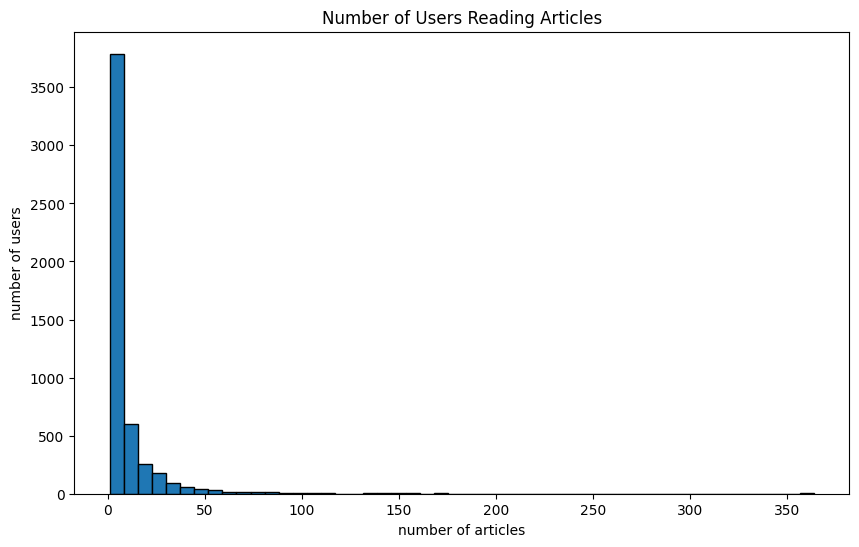

```python
# Create a plot of the number of articles read by each user
plt.figure(figsize=(10, 6))
plt.hist(user_counts, bins=50, edgecolor='k')
plt.xlabel('number of articles')
plt.ylabel('number of users')
plt.title('Number of Users Reading Articles')
plt.show()
```

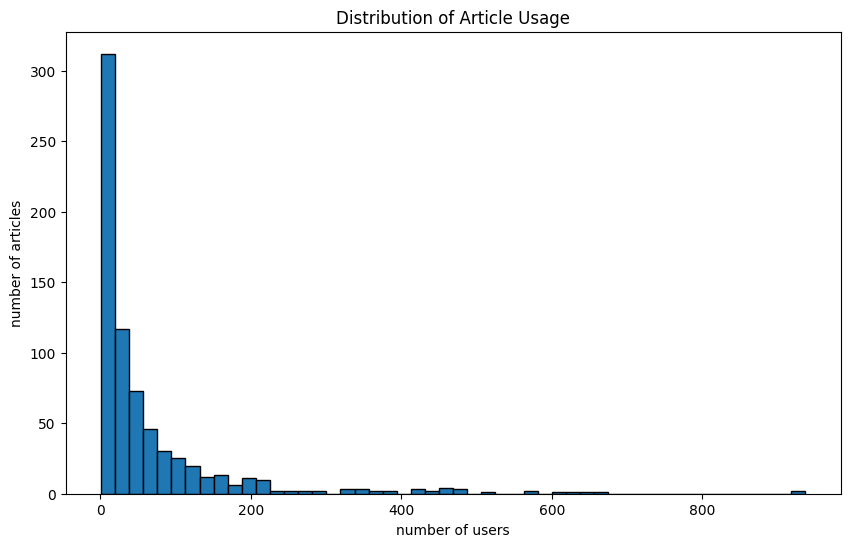

```python
# Create a plot of the number of times each article was read
article_usage = df.groupby('article_id')['email'].count()

plt.figure(figsize=(10, 6))
plt.hist(article_usage, bins=50, edgecolor='k')
plt.xlabel('number of users')
plt.ylabel('number of articles')
plt.title('Distribution of Article Usage')
plt.show()
```

```python
# Fill in the median and maximum number of user_article interactions below

median_val = int(user_counts.median())
print(f"50% of individuals are read by {median_val} users or fewer.")

max_views_by_user = int(user_counts.max())
print(f"The maximum number of user-article interactions for any 1 article is {max_views_by_user}.")
```

```
50% of individuals are read by 3 users or fewer.
The maximum number of user-article interactions for any 1 article is 364.
```

`3.` Use the cells below to find:

**a.** The number of unique articles that have an interaction with a user.  
**b.** The number of unique articles in the dataset (whether they have any interactions or not).  
**c.** The number of unique users in the dataset. (excluding null values)  
**d.** The number of user-article interactions in the dataset.

```python
# The number of unique articles that have at least one interaction
unique_articles = int(df['article_id'].nunique())
# The number of unique articles on the IBM platform
total_articles = int(df['article_id'].unique().shape[0])
# The number of unique users
unique_users = int(df['email'].nunique())
# The number of user-article interactions
user_article_interactions = int(df.shape[0])
print(f"Unique articles with at least one interaction: {unique_articles}")
print(f"Total number of unique articles in the dataset: {total_articles}")
print(f"Unique users: {unique_users}")
print(f"Total user-article interactions: {user_article_interactions}")
```

```
Unique articles with at least one interaction: 714
Total number of unique articles in the dataset: 714
Unique users: 5149
Total user-article interactions: 45993
```

`4.` Use the cells below to find the most viewed **article_id**, as well as how often it was viewed. After talking to the company leaders, the `email_mapper` function was deemed a reasonable way to map users to ids. There were a small number of null values, and it was found that all of these null values likely belonged to a single user (which is how they are stored using the function below).

```python
article_views = df['article_id'].value_counts()
most_viewed_article_id = article_views.idxmax()

# The most viewed article in the dataset was viewed how many times?
max_views = int(article_views.max())

print(f"Most viewed article id: {most_viewed_article_id}")
print(f"Maximum views: {max_views}")
```

```
Most viewed article id: 1429
Maximum views: 937
```

```python
# Map the user email to a user_id column and remove the email column

def email_mapper(df=df):
    coded_dict = {
        email: num
        for num, email in enumerate(df['email'].unique(), start=1)
    }
    return [coded_dict[val] for val in df['email']]

df['user_id'] = email_mapper(df)
del df['email']

# show header
df.head()
```

|  | Unnamed: 0 | article_id | title | user_id |
| --- | --- | --- | --- | --- |
| 0 | 0 | 1430 | using pixiedust for fast, flexible, and easier... | 1 |
| 1 | 1 | 1314 | healthcare python streaming application demo | 2 |
| 2 | 2 | 1429 | use deep learning for image classification | 3 |
| 3 | 3 | 1338 | ml optimization using cognitive assistant | 4 |
| 4 | 4 | 1276 | deploy your python model as a restful api | 5 |

```python
## If you stored all your results in the variable names above,
## you shouldn't need to change anything in this cell

sol_1_dict = {
    '`50% of individuals have _____ or fewer interactions.`': median_val,
    '`The total number of user-article interactions in the dataset is ______.`': user_article_interactions,
    '`The maximum number of user-article interactions by any 1 user is ______.`': max_views_by_user,
    '`The most viewed article in the dataset was viewed _____ times.`': max_views,
    '`The article_id of the most viewed article is ______.`': most_viewed_article_id,
    '`The number of unique articles that have at least 1 rating ______.`': unique_articles,
    '`The number of unique users in the dataset is ______`': unique_users,
    '`The number of unique articles on the IBM platform`': total_articles
}

# Test your dictionary against the solution
t.sol_1_test(sol_1_dict)
```

```
It looks like you have everything right here! Nice job!
```

### Part II: Rank-Based Recommendations

In this project, we don't actually have ratings for whether a user liked an article or not. We only know that a user has interacted with an article. In these cases, the popularity of an article can really only be based on how often an article was interacted with.

`1.` Fill in the function below to return the **n** top articles ordered with most interactions as the top. Test your function using the tests below.

```python
def get_top_articles(n, df=df):
    """
    INPUT:
    n - (int) the number of top articles to return
    df - (pandas dataframe) df as defined at the top of the notebook

    OUTPUT:
    top_articles - (list) A list of the top 'n' article titles

    """
    article_counts = df['article_id'].value_counts()
    top_ids = article_counts.index[:n]
    top_articles = list(df[df['article_id'].isin(top_ids)]
                        .drop_duplicates(subset=['article_id'])
                        .set_index('article_id')
                        .loc[top_ids, 'title'])

    return top_articles # Return the top article titles from df

def get_top_article_ids(n, df=df):
    """
    INPUT:
    n - (int) the number of top articles to return
    df - (pandas dataframe) df as defined at the top of the notebook

    OUTPUT:
    top_articles - (list) A list of the top 'n' article titles

    """
    # Count total interactions per article (each row = one interaction)
    counts = df['article_id'].value_counts()
    top_ids = counts.index[:n]
    # Return as ints to match tests
    return [int(float(a)) for a in top_ids]
```

```python
print(get_top_articles(10))
print(get_top_article_ids(10))
```

[output not shown]

```python
# Test your function by returning the top 5, 10, and 20 articles
top_5 = get_top_articles(5)
top_10 = get_top_articles(10)
top_20 = get_top_articles(20)

# Test each of your three lists from above
t.sol_2_test(get_top_articles)
```

```
Your top_5 looks like the solution list! Nice job.
Your top_10 looks like the solution list! Nice job.
Your top_20 looks like the solution list! Nice job.
```

### Part III: User-User Based Collaborative Filtering

`1.` Use the function below to reformat the **df** dataframe to be shaped with users as the rows and articles as the columns.

- Each **user** should only appear in each **row** once.
- Each **article** should only show up in one **column**.
- **If a user has interacted with an article, then place a 1 where the user-row meets for that article-column**. It does not matter how many times a user has interacted with the article, all entries where a user has interacted with an article should be a 1.
- **If a user has not interacted with an item, then place a zero where the user-row meets for that article-column**.

Use the tests to make sure the basic structure of your matrix matches what is expected by the solution.

```python
# create the user-article matrix with 1's and 0's

def create_user_item_matrix(df, fill_value=0):
    """
    INPUT:
    df - pandas dataframe with article_id, title, user_id columns

    OUTPUT:
    user_item - user item matrix

    Description:
    Return a matrix with user ids as rows and article ids on the columns with 1 values where a user interacted with
    an article and a 0 otherwise
    """

    user_item = df.groupby(['user_id', 'article_id'])['title'].count().unstack().fillna(0)
    user_item = user_item.applymap(lambda x: 1 if x > 0 else fill_value)

    return user_item # return the user_item matrix

user_item = create_user_item_matrix(df)
```

```python
## Tests: You should just need to run this cell.  Don't change the code.
assert user_item.shape[0] == 5149, "Oops!  The number of users in the user-article matrix doesn't look right."
assert user_item.shape[1] == 714, "Oops!  The number of articles in the user-article matrix doesn't look right."
assert user_item.sum(axis=1)[1] == 36, "Oops!  The number of articles seen by user 1 doesn't look right."
print("You have passed our quick tests!  Please proceed!")
```

```
You have passed our quick tests!  Please proceed!
```

`2.` Complete the function below which should take a user_id and provide an ordered list of the most similar users to that user (from most similar to least similar). The returned result should not contain the provided user_id, as we know that each user is similar to him/herself. Because the results for each user here are binary, it (perhaps) makes sense to compute similarity as the dot product of two users.

Use the tests to test your function.

```python
# Lets use the cosine_similarity function from sklearn
from sklearn.metrics.pairwise import cosine_similarity
```

```python
def find_similar_users(user_id, user_item=user_item, include_similarity=False):
    """
    INPUT:
    user_id - (int) a user_id
    user_item - (pandas dataframe) matrix of users by articles:
                1's when a user has interacted with an article, 0 otherwise
    include_similarity - (bool) whether to include the similarity in the output

    OUTPUT:
    similar_users - (list) an ordered list where the closest users (largest dot product users)
                    are listed first

    Description:
    Computes the similarity of every pair of users based on the dot product
    Returns an ordered list of user ids. If include_similarity is True, returns a list of lists
    where the first element is the user id and the second the similarity.

    """

    # compute similarity of each user to the provided user
    target_vec = user_item.loc[user_id].values.reshape(1, -1)
    sims = cosine_similarity(user_item.values, target_vec).ravel()

    # sort by similarity
    # remove the own user's id
    sim_df = pd.DataFrame({
        'user_id': user_item.index,
        'similarity': sims
    })

    # create list of just the ids
    sim_df = sim_df[sim_df['user_id'] != user_id]

    # create list of just the similarities
    sim_df = sim_df.sort_values(by=['similarity', 'user_id'], ascending=[False, True])

    if include_similarity:
        return sim_df[['user_id', 'similarity']].values.tolist()

    most_similar_users = sim_df['user_id'].tolist()
    # return a list of the users in order from most to least similar
    return most_similar_users
```

```python
# Do a spot check of your function
print("The 10 most similar users to user 1 are: {}".format(find_similar_users(1)[:10]))
print("The 5 most similar users to user 3933 are: {}".format(find_similar_users(3933)[:5]))
print("The 3 most similar users to user 46 are: {}".format(find_similar_users(46)[:3]))
```

```
The 10 most similar users to user 1 are: [3933, 46, 4201, 253, 824, 5034, 5041, 136, 2305, 395]
The 5 most similar users to user 3933 are: [1, 46, 4201, 253, 824]
The 3 most similar users to user 46 are: [4201, 790, 5077]
```

`3.` Now that you have a function that provides the most similar users to each user, you will want to use these users to find articles you can recommend. Complete the functions below to return the articles you would recommend to each user.

```python
def get_article_names(article_ids, df=df):
    """
    INPUT:
    article_ids - (list) a list of article ids
    df - (pandas dataframe) df as defined at the top of the notebook

    OUTPUT:
    article_names - (list) a list of article names associated with the list of article ids
    """
    # Map each article_id to its corresponding title
    id_to_title = (df[['article_id', 'title']]
                   .drop_duplicates(subset=['article_id'])
                   .set_index('article_id')['title'])
    article_names = [id_to_title.get(aid) for aid in article_ids]
    return article_names


def get_ranked_article_unique_counts(article_ids, user_item=user_item):
    """
    OUTPUT:
    ranked_article_unique_counts - (list) [[article_id, unique_user_count], ...]
                                   sorted by unique_user_count (descending)
    """
    counts = []
    for aid in article_ids:
        if aid in user_item.columns:
            counts.append([aid, int(user_item[aid].sum())])
    # Sort by unique user count (descending), then article_id (ascending)
    ranked_article_unique_counts = sorted(counts, key=lambda x: (-x[1], x[0]))
    return ranked_article_unique_counts


def get_user_articles(user_id, user_item=user_item):
    """
    OUTPUT:
    article_ids   - (list) article ids seen by the user
    article_names - (list) article titles associated with the article ids
    """
    # Select articles where the user has interacted (value = 1)
    seen_mask = user_item.loc[user_id] == 1
    article_ids = user_item.columns[seen_mask].tolist()
    article_names = get_article_names(article_ids, df=df)
    return article_ids, article_names


def user_user_recs(user_id, m=10):
    """
    OUTPUT:
    recs - (list) a list of recommended article ids for the user (length up to m)
    """
    # Articles the target user has already seen
    seen_ids, _ = get_user_articles(user_id, user_item=user_item)
    seen_set = set(seen_ids)

    # Find most similar users
    similar_users = find_similar_users(user_id, user_item=user_item, include_similarity=False)

    recs = []
    added = set()

    # Add unseen articles from similar users
    for u in similar_users:
        other_ids, _ = get_user_articles(u, user_item=user_item)
        for aid in other_ids:
            if aid not in seen_set and aid not in added:
                recs.append(aid)
                added.add(aid)
                if len(recs) >= m:
                    return recs

    # If still not enough, fill with most popular articles
    popular_ids = df['article_id'].value_counts().index.tolist()
    for aid in popular_ids:
        if aid not in seen_set and aid not in added:
            recs.append(aid)
            added.add(aid)
            if len(recs) >= m:
                break

    return recs
```

```python
# Check Results
get_article_names(user_user_recs(1, 10)) # Return 10 recommendations for user 1
```

```
['this week in data science (april 18, 2017)',
 'this week in data science (may 2, 2017)',
 'top 20 r machine learning and data science packages',
 'improving the roi of big data and analytics through leveraging new sources of data',
 'using apply, sapply, lapply in r',
 'awesome deep learning papers',
 'leverage python, scikit, and text classification for behavioral profiling',
 'challenges in deep learning',
 'do i need to learn r?',
 'how can data scientists collaborate to build better business']
```

```python
get_ranked_article_unique_counts([1320, 232, 844])
```

```
[[1320, 123], [844, 78], [232, 62]]
```

```python
# Test your functions here - No need to change this code - just run this cell
assert set(get_article_names([1024, 1176, 1305, 1314, 1422, 1427])) == set(['using deep learning to reconstruct high-resolution audio', 'build a python app on the streaming analytics service', 'gosales transactions for naive bayes model', 'healthcare python streaming application demo', 'use r dataframes & ibm watson natural language understanding', 'use xgboost, scikit-learn & ibm watson machine learning apis']), "Oops! Your the get_article_names function doesn't work quite how we expect."
assert set(get_article_names([1320, 232, 844])) == set(['housing (2015): united states demographic measures','self-service data preparation with ibm data refinery','use the cloudant-spark connector in python notebook']), "Oops! Your the get_article_names function doesn't work quite how we expect."
assert set(get_user_articles(20)[0]) == set([1320, 232, 844])
assert set(get_user_articles(20)[1]) == set(['housing (2015): united states demographic measures', 'self-service data preparation with ibm data refinery','use the cloudant-spark connector in python notebook'])
assert set(get_user_articles(2)[0]) == set([1024, 1176, 1305, 1314, 1422, 1427])
assert set(get_user_articles(2)[1]) == set(['using deep learning to reconstruct high-resolution audio', 'build a python app on the streaming analytics service', 'gosales transactions for naive bayes model', 'healthcare python streaming application demo', 'use r dataframes & ibm watson natural language understanding', 'use xgboost, scikit-learn & ibm watson machine learning apis'])
assert get_ranked_article_unique_counts([1320, 232, 844])[0] == [1320, 123], "Oops! Your the get_ranked_article_unique_counts function doesn't work quite how we expect.\nMake sure you are using the user_item matrix to create the article counts."
print("If this is all you see, you passed all of our tests!  Nice job!")
```

```
If this is all you see, you passed all of our tests!  Nice job!
```

`4.` Now we are going to improve the consistency of the **user_user_recs** function from above.

- Instead of arbitrarily choosing when we obtain users who are all the same closeness to a given user - choose the users that have the most total article interactions before choosing those with fewer article interactions.
- Instead of arbitrarily choosing articles from the user where the number of recommended articles starts below m and ends exceeding m, choose articles with the articles with the most total interactions before choosing those with fewer total interactions. This ranking should be what would be obtained from the **top_articles** function you wrote earlier.

```python
def get_top_sorted_users(user_id, user_item=user_item):
    """
    INPUT:
    user_id - (int)
    user_item - (pandas dataframe) matrix of users by articles:
            1's when a user has interacted with an article, 0 otherwise


    OUTPUT:
    neighbors_df - (pandas dataframe) a dataframe with:
                    neighbor_id - is a neighbor user_id
                    similarity - measure of the similarity of each user to the provided user_id
                    num_interactions - the number of articles viewed by the user

    Other Details - sort the neighbors_df by the similarity and then by number of interactions where
                    highest of each is higher in the dataframe, i.e. Descending order

    """
    # Compute similarity with all users
    sims = cosine_similarity(user_item.loc[user_id].values.reshape(1, -1),
                             user_item.values).flatten()

    # Create dataframe of neighbors (exclude self)
    neighbors_df = pd.DataFrame({
        'neighbor_id': user_item.index,
        'similarity': sims,
        'num_interactions': user_item.sum(axis=1).values
    })
    neighbors_df = neighbors_df[neighbors_df['neighbor_id'] != user_id]

    # Sort by similarity, then by number of interactions
    neighbors_df = neighbors_df.sort_values(
        by=['similarity', 'num_interactions'],
        ascending=[False, False]
    )

    return neighbors_df # Return the dataframe specified in the doc_string


def user_user_recs_part2(user_id, m=10):
    """
    INPUT:
    user_id - (int) a user id
    m - (int) the number of recommendations you want for the user

    OUTPUT:
    recs - (list) a list of recommendations for the user by article id
    rec_names - (list) a list of recommendations for the user by article title

    Description:
    Loops through the users based on closeness to the input user_id
    For each user - finds articles the user hasn't seen before and provides them as recs
    Does this until m recommendations are found

    Notes:
    * Choose the users that have the most total article interactions
    before choosing those with fewer article interactions.

    * Choose articles with the articles with the most total interactions
    before choosing those with fewer total interactions.

    """
    # Articles the target user has already seen
    seen_ids, _ = get_user_articles(user_id, user_item=user_item)
    seen_set = set(seen_ids)

    recs = []
    added = set()

    # Get neighbors sorted properly
    neighbors_df = get_top_sorted_users(user_id, user_item=user_item)

    # Collect unseen articles from top neighbors
    for neighbor in neighbors_df['neighbor_id']:
        other_ids, _ = get_user_articles(neighbor, user_item=user_item)
        for aid in other_ids:
            if aid not in seen_set and aid not in added:
                recs.append(aid)
                added.add(aid)
            if len(recs) >= m:
                break
        if len(recs) >= m:
            break

    if recs:
        ranked = get_ranked_article_unique_counts(recs, user_item=user_item)
        recs = [aid for aid, _ in ranked[:m]]

    # If fewer than m, fill with top popular articles (역시 get_ranked_article_unique_counts로)
    if len(recs) < m:
        remaining_needed = m - len(recs)
        top_articles = get_top_article_ids(100, df)  # take many to be safe
        # 이미 추천/본 기사 제외
        fill_candidates = [aid for aid in top_articles if aid not in seen_set and aid not in recs]
        ranked_fill = get_ranked_article_unique_counts(fill_candidates, user_item=user_item)
        recs.extend([aid for aid, _ in ranked_fill[:remaining_needed]])

    return recs, get_article_names(recs) # return your recommendations for this user_id
```

```python
# Quick spot check - don't change this code - just use it to test your functions
rec_ids, rec_names = user_user_recs_part2(20, 10)
print("The top 10 recommendations for user 20 are the following article ids:")
print(rec_ids)
print()
print("The top 10 recommendations for user 20 are the following article names:")
print(rec_names)
```

[output not shown]

`5.` Use your functions from above to correctly fill in the solutions to the dictionary below. Then test your dictionary against the solution. Provide the code you need to answer each following the comments below.

```python
print(get_top_sorted_users(1, user_item=user_item).head(n=1))
print(get_top_sorted_users(2, user_item=user_item).head(n=10))
print(get_top_sorted_users(131, user_item=user_item).head(n=10))
```

```
      neighbor_id  similarity  num_interactions
3932         3933    0.986013                35
      neighbor_id  similarity  num_interactions
5082         5083    0.730297                 5
1551         1552    0.577350                 2
1889         1890    0.577350                 2
1371         1372    0.471405                 3
2940         2941    0.433013                 8
3585         3586    0.408248                 4
330           331    0.408248                 1
347           348    0.408248                 1
377           378    0.408248                 1
495           496    0.408248                 1
      neighbor_id  similarity  num_interactions
3869         3870    0.986667                75
202           203    0.388909                96
4458         4459    0.388909                96
3781         3782    0.387585               135
39             40    0.384308                52
4931         4932    0.384308                52
22             23    0.377647               135
241           242    0.375823                59
3909         3910    0.372678                60
382           383    0.367423                32
```

```python
### Tests with a dictionary of results
user1_most_sim =  int(get_top_sorted_users(1, user_item=user_item).iloc[0]['neighbor_id'])
user2_6th_sim =  int(get_top_sorted_users(2, user_item=user_item).iloc[5]['neighbor_id'])
user131_10th_sim =  int(get_top_sorted_users(131, user_item=user_item).iloc[9]['neighbor_id'])
```

```python
## Dictionary Test Here
sol_5_dict = {
    'The user that is most similar to user 1.': user1_most_sim,
    'The user that is the 6th most similar to user 2.': user2_6th_sim,
    'The user that is the 10th most similar to user 131.': user131_10th_sim,
}

t.sol_5_test(sol_5_dict)
```

```
This all looks good!  Nice job!
```

`6.` If we were given a new user, which of the above functions would you be able to use to make recommendations? Explain. Can you think of a better way we might make recommendations? Use the cell below to explain a better method for new users.

Answer:

For a new user, the functions based on collaborative filtering, such as get_user_articles, find_similar_users, or user_user_recs_part2, cannot be applied because the user has no interaction history. The only usable functions would be rank-based approaches, such as get_top_articles or get_top_article_ids, since they do not require any prior user information and simply return the most popular items overall.

However, this is not always the best method for personalization. A better way to make recommendations for new users is to use content-based filtering. For example, we could recommend articles based on metadata such as article tags, topics, or descriptions. If we have some demographic or contextual information about the user (e.g., location, profession, or device type), we can also use that to personalize the recommendations. Another practical approach is to use a hybrid method, where we combine popularity-based recommendations initially, then gradually transition to collaborative filtering as the user begins to interact with articles.

`7.` Using your existing functions, provide the top 10 recommended articles you would provide for the a new user below. You can test your function against our thoughts to make sure we are all on the same page with how we might make a recommendation.

```python
# What would your recommendations be for this new user 0?  As a new user, they have no observed articles.
# Provide a list of the top 10 article ids you would give to
new_user_recs = get_top_article_ids(10, df)
new_user_recs
```

```
[1429, 1330, 1431, 1427, 1364, 1314, 1293, 1170, 1162, 1304]
```

```python
assert set(new_user_recs) == {1314, 1429, 1293, 1427, 1162, 1364, 1304, 1170, 1431, 1330}, "Oops!  It makes sense that in this case we would want to recommend the most popular articles, because we don't know anything about these users."

print("That's right!  Nice job!")
```

```
That's right!  Nice job!
```

### Part IV: Content Based Recommendations

Another method we might use to make recommendations is to recommend similar articles that are possibly related. One way we can find article relationships is by clustering text about those articles. Let's consider content to be the article **title**, as it is the only text we have available. One point to highlight, there isn't one way to create a content based recommendation, especially considering that text information can be processed in many ways.

`1.` Use the function bodies below to create a content based recommender function `make_content_recs`. We'll use TF-IDF to create a matrix based off article titles, and use this matrix to create clusters of related articles. You can use this function to make recommendations of new articles.

```python
df.head()
```

|  | Unnamed: 0 | article_id | title | user_id |
| --- | --- | --- | --- | --- |
| 0 | 0 | 1430 | using pixiedust for fast, flexible, and easier... | 1 |
| 1 | 1 | 1314 | healthcare python streaming application demo | 2 |
| 2 | 2 | 1429 | use deep learning for image classification | 3 |
| 3 | 3 | 1338 | ml optimization using cognitive assistant | 4 |
| 4 | 4 | 1276 | deploy your python model as a restful api | 5 |

```python
from sklearn.cluster import KMeans
from sklearn.feature_extraction.text import TfidfVectorizer
from sklearn.pipeline import make_pipeline
from sklearn.preprocessing import Normalizer
from sklearn.decomposition import TruncatedSVD
```

```python
# unique articles
df_unique_articles = df[['article_id', 'title']].drop_duplicates(subset='article_id').reset_index(drop=True)
print(f"Unique articles: {df_unique_articles.shape[0]}")
df_unique_articles.head()
```

```
Unique articles: 714
```

|  | article_id | title |
| --- | --- | --- |
| 0 | 1430 | using pixiedust for fast, flexible, and easier... |
| 1 | 1314 | healthcare python streaming application demo |
| 2 | 1429 | use deep learning for image classification |
| 3 | 1338 | ml optimization using cognitive assistant |
| 4 | 1276 | deploy your python model as a restful api |

```python
# Create a vectorizer using TfidfVectorizer and fit it to the article titles
max_features = 200
max_df = 0.75
min_df = 5

vectorizer = TfidfVectorizer(
    max_df=max_df,
    min_df=min_df,
    stop_words="english",
    max_features=max_features,
)
print("Running TF-IDF")

# Fit and transform the article titles using TF-IDF
X_tfidf =  vectorizer.fit_transform(df_unique_articles['title'])

print(f"n_samples: {X_tfidf.shape[0]}, n_features: {X_tfidf.shape[1]}")

# Build the LSA pipeline and fit-transform
lsa = make_pipeline(TruncatedSVD(n_components=50), Normalizer(copy=False))
X_lsa = lsa.fit_transform(X_tfidf)
explained_variance = lsa[0].explained_variance_ratio_.sum()

print(f"Explained variance of the SVD step: {explained_variance * 100:.1f}%")
```

```
Running TF-IDF
n_samples: 714, n_features: 125
Explained variance of the SVD step: 76.0%
```

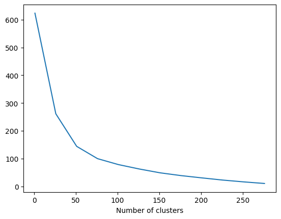

```python
# Let's map the inertia for different number of clusters to find the optimal number of clusters
# We'll plot it to see the elbow
inertia = []
clusters = 300
step = 25
max_iter = 50
n_init = 5
random_state = 42
for k in range(1, clusters, step):
    kmeans = KMeans(
        n_clusters=k,
        max_iter=max_iter,
        n_init=n_init,
        random_state=random_state,
    ).fit(X_lsa)
    # inertia is the sum of squared distances to the closest cluster center
    inertia.append(kmeans.inertia_)
plt.plot(range(1, clusters, step), inertia)
plt.xlabel('Number of clusters')
```

```python
n_clusters = 75
kmeans = KMeans(
    n_clusters=n_clusters,
    max_iter=max_iter,
    n_init=n_init,
    random_state=random_state,
).fit(X_lsa)
```

```python
# create a new column `title_cluster` and assign it the kmeans cluster labels
# First we need to map the labels to df_unique_articles article ids and then apply those to df
article_cluster_map = dict(zip(df_unique_articles['article_id'], kmeans.labels_))
df['title_cluster'] = df['article_id'].map(article_cluster_map)

print(df[['article_id', 'title', 'title_cluster']].head())
```

```
   article_id                                              title  \
0        1430  using pixiedust for fast, flexible, and easier...
1        1314       healthcare python streaming application demo
2        1429         use deep learning for image classification
3        1338          ml optimization using cognitive assistant
4        1276          deploy your python model as a restful api

   title_cluster
0             63
1             71
2             14
3              9
4             44
```

```python
# Let's check the number of articles in each cluster
np.array(np.unique(kmeans.labels_, return_counts=True)).T
```

```
array([[ 0,  4],
       [ 1,  2],
       [ 2,  9],
       [ 3, 49],
       [ 4, 23],
       [ 5, 28],
       [ 6, 28],
       [ 7, 20],
       [ 8, 14],
       [ 9, 15],
       [10, 15],
       [11, 24],
       [12, 17],
       [13, 14],
       [14, 18],
```

[output cut: 60 more lines]

```python
def get_similar_articles(article_id, df=df):
    """
    INPUT:
    article_id - (int) an article id
    df - (pandas dataframe) df as defined at the top of the notebook

    OUTPUT:
    article_ids - (list) a list of article ids that are in the same title cluster

    Description:
    Returns a list of the article ids that are in the same title cluster
    """
    # find the cluster of the given article_id
    title_cluster_series = df.loc[df['article_id'] == article_id, 'title_cluster']
    if title_cluster_series.empty:
        return []
    title_cluster = title_cluster_series.iloc[0]

    # all article_ids in the same cluster
    articles_in_cluster = (
        df.loc[df['title_cluster'] == title_cluster, 'article_id']
          .drop_duplicates()
          .tolist()
    )

    # remove the input article_id itself
    articles_in_cluster = [aid for aid in articles_in_cluster if aid != article_id]
    return articles_in_cluster
```

```python
def make_content_recs(article_id, n, df=df):
    """
    INPUT:
    article_id - (int) an article id
    n - (int) the number of recommendations you want similar to the article id
    df - (pandas dataframe) df as defined at the top of the notebook

    OUTPUT:
    n_ranked_similar_articles - (list) a list of article ids that are in the same title cluster ranked
                                by popularity
    n_ranked_article_names - (list) a list of article names associated with the list of article ids

    Description:
    Returns a list of the n most ranked similar articles to a given article_id based on the title
    cluster in df. Rank similar articles using the function get_ranked_article_unique_counts.
    """
    # candidates: same-cluster articles
    candidates = get_similar_articles(article_id, df=df)

    # rank by unique-user counts using user_item (already created earlier)
    ranked = get_ranked_article_unique_counts(candidates, user_item=user_item)  # [[aid, count], ...] desc
    n_ranked_similar_articles = [row[0] for row in ranked[:n]]

    # if not enough, fill with global popular articles (excluding duplicates and the input article)
    if len(n_ranked_similar_articles) < n:
        need = n - len(n_ranked_similar_articles)
        have = set(n_ranked_similar_articles)
        global_pop_ids = df['article_id'].value_counts().index.tolist()
        for aid in global_pop_ids:
            if aid == article_id:
                continue
            if aid in have:
                continue
            n_ranked_similar_articles.append(aid)
            have.add(aid)
            if len(n_ranked_similar_articles) >= n:
                break

    # map to titles
    n_ranked_article_names = get_article_names(n_ranked_similar_articles, df=df)
    return n_ranked_similar_articles, n_ranked_article_names
```

```python
# Test out your content recommendations given artice_id 25
rec_article_ids, rec_article_titles = make_content_recs(25, 10)
print(rec_article_ids)
print(rec_article_titles)
```

[output not shown]

```python
assert len({1025, 593, 349, 821, 464, 29, 1042, 693, 524, 352}.intersection(set(rec_article_ids))) > 0, "Oops! Your the make_content_recs function doesn't work quite how we expect."
```

`2.` Now that you have put together your content-based recommendation system, use the cell below to write a summary explaining how your content based recommender works. Do you see any possible improvements that could be made to your function? What other text data would be useful to help make better recommendations besides the article title?

Our content-based recommender uses TF-IDF to convert article titles into a vector space, then applies TruncatedSVD and KMeans to cluster similar articles together. For a given article, we find all articles in the same cluster and rank them by their popularity (unique user interactions). Finally, we return the top N ranked articles and their titles.

Possible improvements:

- Use more advanced embeddings to capture deeper semantic meaning.
- Include article body text, summaries, or tags instead of just titles to improve clustering quality.
- Weight recency to recommend newer but still relevant articles.

Additional useful text data:

- Full article content
- Author keywords or categories
- User-provided tags and comments

### Part V: Matrix Factorization

In this part of the notebook, you will build use matrix factorization to make article recommendations to users.

`1.` You should have already created a **user_item** matrix above in **question 1** of **Part III** above. This first question here will just require that you run the cells to get things set up for the rest of **Part V** of the notebook.

```python
# quick look at the matrix
user_item.head()
```

| article_id user_id | 0 | 2 | 4 | 8 | 9 | 12 | 14 | 15 | 16 | 18 | ... | 1434 | 1435 | 1436 | 1437 | 1439 | 1440 | 1441 | 1442 | 1443 | 1444 |
| --- | --- | --- | --- | --- | --- | --- | --- | --- | --- | --- | --- | --- | --- | --- | --- | --- | --- | --- | --- | --- | --- |
| 1 | 0 | 0 | 0 | 0 | 0 | 0 | 0 | 0 | 0 | 0 | ... | 0 | 0 | 1 | 0 | 1 | 0 | 0 | 0 | 0 | 0 |
| 2 | 0 | 0 | 0 | 0 | 0 | 0 | 0 | 0 | 0 | 0 | ... | 0 | 0 | 0 | 0 | 0 | 0 | 0 | 0 | 0 | 0 |
| 3 | 0 | 0 | 0 | 0 | 0 | 1 | 0 | 0 | 0 | 0 | ... | 0 | 0 | 1 | 0 | 0 | 0 | 0 | 0 | 0 | 0 |
| 4 | 0 | 0 | 0 | 0 | 0 | 0 | 0 | 0 | 0 | 0 | ... | 0 | 0 | 0 | 0 | 0 | 0 | 0 | 0 | 0 | 0 |
| 5 | 0 | 0 | 0 | 0 | 0 | 0 | 0 | 0 | 0 | 0 | ... | 0 | 0 | 0 | 0 | 0 | 0 | 0 | 0 | 0 | 0 |

5 rows × 714 columns

`2.` In this situation, you can use Singular Value Decomposition from [scikit-learn](https://scikit-learn.org/stable/modules/generated/sklearn.decomposition.TruncatedSVD.html) on the user-item matrix. Use the cell to perform SVD.

```python
from sklearn.decomposition import TruncatedSVD
from sklearn.metrics import precision_score, recall_score, accuracy_score
# Using the full number of components which equals the number of columns
svd = TruncatedSVD(n_components=len(user_item.columns), n_iter=5, random_state=42)

u = svd.fit_transform(user_item)
v = svd.components_
s = svd.singular_values_
print('u', u.shape)
print('s', s.shape)
print('vt', v.shape)
```

```
u (5149, 714)
s (714,)
vt (714, 714)
```

`3.` Now for the tricky part, how do we choose the number of latent features to use? Running the below cell, you can see that as the number of latent features increases, we obtain better metrics when making predictions for the 1 and 0 values in the user-item matrix. Run the cell below to get an idea of how our metrics improve as we increase the number of latent features.

We can choose the number of latent features by evaluating model performance metrics such as precision, recall, and accuracy as the number of features increases. We typically plot these metrics against the number of features and look for the point where performance improvements begin to level off (the “elbow point”). This allows us to select a number of features that balances model complexity and generalization without overfitting.

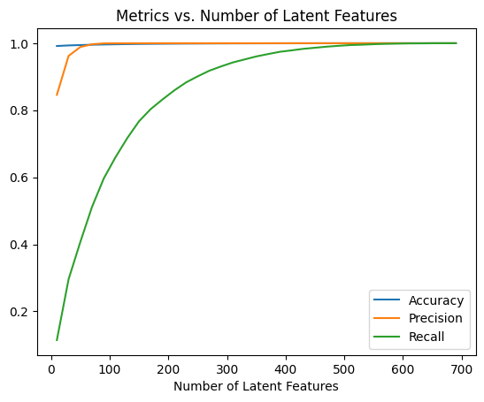

```python
num_latent_feats = np.arange(10, 700+10, 20)
metric_scores = []

for k in num_latent_feats:
    # restructure with k latent features
    u_new, vt_new = u[:, :k], v[:k, :]

    # take dot product
    user_item_est = abs(np.around(np.dot(u_new, vt_new))).astype(int)
    # make sure the values are between 0 and 1
    user_item_est = np.clip(user_item_est, 0, 1)

    # total errors and keep track of them
    acc = accuracy_score(user_item.values.flatten(), user_item_est.flatten())
    precision = precision_score(user_item.values.flatten(), user_item_est.flatten())
    recall = recall_score(user_item.values.flatten(), user_item_est.flatten())
    metric_scores.append([acc, precision, recall])


plt.plot(num_latent_feats, metric_scores, label=['Accuracy', 'Precision', 'Recall'])
plt.legend()
plt.xlabel('Number of Latent Features')
plt.title('Metrics vs. Number of Latent Features')
```

`4.` From the above, we can't really be sure how many features to use, because simply having a better way to predict the 1's and 0's of the matrix doesn't exactly give us an indication of if we are able to make good recommendations. Given the plot above, what would you pick for the number of latent features and why?

Based on the plot:

- **Accuracy** and **Precision** quickly reach ~1.0 by around **100 latent features**, with minimal improvement beyond that point.
- **Recall** continues to improve gradually but starts to plateau after ~300 features.

**Choice:**  
I would choose around **150–200 latent features** because:

- It achieves near-maximum Accuracy and Precision.
- It provides a good trade-off between Recall improvement and computational efficiency.
- Using too many features may lead to unnecessary complexity and potential overfitting.

`5.` Using 200 latent features and the values of U, S, and V transpose we calculated above, create an article id recommendation function that finds similar article ids to the one provide.

Create a list of 10 recommendations that are similar to article with id 4. The function should provide these recommendations by finding articles that have the most similar latent features as the provided article.

```python
def get_svd_similar_article_ids(article_id, vt, user_item=user_item, include_similarity=False):
    """
    INPUT:
    article_id - (int) an article id
    vt - (numpy array) vt matrix from SVD
    user_item - (pandas dataframe) matrix of users by articles:
                1's when a user has interacted with an article, 0 otherwise
    include_similarity - (bool) whether to include the similarity in the output

    OUTPUT:
    article_ids - (list) a list of article ids that are in the same title cluster

    Description:
    Returns a list of the article ids similar using SVD factorization
    """
    cols = list(user_item.columns)
    if article_id in cols:
        article_idx = cols.index(article_id)
    else:

        try_ids = [article_id, float(article_id), int(float(article_id))]
        found = None
        for cand in try_ids:
            if cand in cols:
                found = cand
                break
        if found is None:
            return [] if not include_similarity else []
        article_idx = cols.index(found)

    #    vt: (n_components, n_articles) -> vt[:k, :].T: (n_articles, k)
    A = vt[:k, :].T

    cos_sim = cosine_similarity(A)
    sims = cos_sim[article_idx]
    order = np.argsort(-sims)
    order = [i for i in order if i != article_idx]

    if include_similarity:
        most_similar_items = [[cols[i], float(sims[i])] for i in order]
    else:
        most_similar_items = [cols[i] for i in order]
    return most_similar_items
```

```python
# Create a vt_new matrix with 200 latent features
k = 200
vt_new = v[:k, :]
```

```python
# What is the article name for article_id 4?
print("Current article:", get_article_names([4], df=df)[0])
```

```
Current article: analyze ny restaurant data using spark in dsx
```

```python
# What are the top 10 most similar articles to article_id 4?
rec_articles = get_svd_similar_article_ids(4, vt_new, user_item=user_item)[:10]
rec_articles
```

```
[1199, 1068, 486, 1202, 176, 1120, 244, 793, 58, 132]
```

```python
# What are the top 10 most similar articles to article_id 4?
get_article_names(rec_articles, df=df)
```

```
['country statistics: crude oil - exports',
 'airbnb data for analytics: athens reviews',
 'use spark r to load and analyze data',
 'country statistics: crude oil - proved reserves',
 'top analytics tools in 2016',
 'airbnb data for analytics: paris calendar',
 'notebooks: a power tool for data scientists',
 '10 powerful features on watson data platform, no coding necessary',
 'advancements in the spark community',
 'collecting data science cheat sheets']
```

```python
assert set(rec_articles) == {1199, 1068, 486, 1202, 176, 1120, 244, 793, 58, 132}, "Oops! Your the get_svd_similar_article_ids function doesn't work quite how we expect."
print("That's right!  Great job!")
```

```
That's right!  Great job!
```

`6.` Use the cell below to comment on the results you found in the previous question. Given the circumstances of your results, discuss what you might do to determine if the recommendations you make above are an improvement to how users currently find articles, either by Sections 2, 3, or 4? Add any tradeoffs between each of the methods, and how you could leverage each type for different situations including new users with no history, recently new users with little history, and users with a lot of history.

### Evaluation of SVD-Based Recommendations

The SVD-based recommendations appear promising, as they capture latent relationships between articles and users beyond explicit interactions. However, to determine if these recommendations improve user experience compared to Sections 2–4, we should run **A/B tests** or **offline metrics** such as precision@k, recall@k, and NDCG on a hold-out validation set.

### Comparison with Other Methods

- **Rank-Based (Section 2)**: Simple and effective for new users but lacks personalization.
- **User-User Collaborative Filtering (Section 3)**: Captures similarity between users but struggles with cold-start users.
- **Content-Based (Section 4)**: Works for new users if they have read at least one article but limited to available text features.

### Trade-offs & Strategy

- **New Users (No History)**: Recommend top-ranked popular articles or use content-based recs if they have clicked on at least one article.
- **Users with Limited History**: Combine collaborative filtering with content-based recommendations (hybrid approach).
- **Users with Rich History**: Use SVD-based latent factor recommendations for deeper personalization, as they capture hidden preferences.

Overall, a **hybrid recommendation system** that uses rank-based recs for cold-start, content-based for light users, and SVD/CF for heavy users would provide the most balanced and scalable solution.

```python
from subprocess import call
call(['python', '-m', 'nbconvert', 'Recommendations_with_IBM.ipynb', '--to', 'html'])
```

```
[NbConvertApp] Converting notebook Recommendations_with_IBM.ipynb to html
[NbConvertApp] WARNING | Alternative text is missing on 4 image(s).
[NbConvertApp] Writing 571559 bytes to Recommendations_with_IBM.html
```

```
0
```